# Building a chess engine with Tensorflow and Alpha-Beta Search

## by Denis Osipychev < www.denisos.com >

This is a step-by-step demonstration of a chess-engine development inspired by the Deep Blue Algorithm by IBM. The Deep Blue utilized a parallel Alpha-Beta Search with AI based function approximation.

## 1. Import and install all the dependencies we need

```python
# install the packages right from jupyter notebook in case if you missing something
# !pip install HDF5Matrix

import numpy as np
import chess
import chess.pgn
import copy
import h5py
import matplotlib.pyplot as plt
import tensorflow as tf
from tensorflow import keras
```

## 2. Create and preproccess the dataset

This step includes transcripting the chess PGN database into a numpy array and saving it into a hdf5 database. The database can be found here < https://www.kingbase-chess.net >. The process is done in chunks, the complete dataset is too large.

```python
dict_of_pieces = {'p': (0, -1), 'P': (0, 1), # pawn
                      'r': (1, -1), 'R': (1, 1), # rook
                      'n': (2, -1), 'N': (2, 1), # knight
                      'b': (3, -1), 'B': (3, 1), # bishop
                      'q': (4, -1), 'Q': (4, 1), # queen
                      'k': (5, -1), 'K': (5, 1)} # king

# transcribing chess board into multichannel sample
def board2sample(board):

    # not taking turn into account
    #sample = np.zeros((8, 8, 6))

    # taking turn into prediction
    sample = np.zeros((8, 8, 7))
    if board.turn: sample[:,:,-1] = 1
    else: sample[:,:,-1] = -1

    board_str = str(board).replace(" ", "").replace("\n", "").replace(".", "0")
    for row_idx in range(8):
        for col_idx in range(8):
            piece = board_str[row_idx*8+col_idx]
            if piece == '0':
                continue
            attr = dict_of_pieces[piece]
            sample[row_idx, col_idx, attr[0]] = attr[1]
    return sample
```

```python
# transcribing multichannel sample back to chess board
def sample2board(s):

    sample = s.astype(int)

    val_list = list(dict_of_pieces.values())
    keys_list = list(dict_of_pieces.keys())

    board_fen = ""
    k = 0
    for row_idx in range(8):
        for col_idx in range(8):
            piece = None

            for chn_idx in range(6):
                color = sample[row_idx, col_idx, chn_idx]
                if color != 0:
                    idx = val_list.index((chn_idx, color))
                    piece = keys_list[idx]
                    break

            if piece is None:
                k += 1
                continue

            if k != 0:
                board_fen += str(k)
                k = 0
            board_fen += str(piece)

        if k != 0:
            board_fen += str(k)
            k = 0
        board_fen += "/"

    return chess.Board(board_fen[:-1])
```

```python
# test data parsing with forth and back conversion
b1 = chess.Board()
b2 = sample2board(board2sample(b1))
print(b1, '\n \n', b2)
```

```
r n b q k b n r
p p p p p p p p
. . . . . . . .
. . . . . . . .
. . . . . . . .
. . . . . . . .
P P P P P P P P
R N B Q K B N R

 r n b q k b n r
p p p p p p p p
. . . . . . . .
. . . . . . . .
. . . . . . . .
. . . . . . . .
P P P P P P P P
R N B Q K B N R
```

```python
%%time

def read_games(pgn_file, hdf5_file, chunk_size=1000, shuffle=False):

    X_buffer, Y_buffer = [], []

    pgn = open(pgn_file)
    hdf = h5py.File(hdf5_file, 'a')
    hdf.create_dataset("data", shape=(0,8,8,7), maxshape=(None, 8, 8, 7), dtype='int')
    hdf.create_dataset("label", shape=(0, 1), maxshape=(None, 1), dtype='int')

    k = 0
    while True:

        try:
            game = chess.pgn.read_game(pgn)
        except:
            break

        if game is None: break

        result = game.headers['Result']

        # skip the games that ended a draw
        if result =='1/2-1/2': continue

        # start a new board and make step by step
        board = game.board()
        for move in game.mainline_moves():
            k += 1
            board.push(move)

            X_buffer.append(board2sample(board)) # transcribe the board into channels
            if result == '1-0': Y_buffer.append(1)  # white win
            elif result == '0-1': Y_buffer.append(0) # white lose

            if (k % chunk_size == 0):
                X_np = np.asarray(X_buffer)
                Y_np = np.expand_dims(np.asarray(Y_buffer), axis=1)

                indices = np.arange(chunk_size)

                #!!! shuffling is done inside the chunk only, so use very large chunks!!!
                if shuffle: np.random.shuffle(indices)

                # expand database and append data
                hdf["data"].resize((hdf["data"].shape[0] + X_np.shape[0]), axis = 0)
                hdf["label"].resize((hdf["label"].shape[0] + Y_np.shape[0]), axis = 0)
                hdf["data"][-X_np.shape[0]:] = X_np[indices,:]
                hdf["label"][-Y_np.shape[0]:] = Y_np[indices,:]

                X_buffer, Y_buffer = [], []

                print("Boards parsed from the dataset: ", hdf["data"].shape[0], ".", end="\r", flush=True)

    pgn.close()
    hdf.close()
    return True

# remove old file and create a new one
!rm train.hdf5
print("\nParsing complete: ", read_games('./train.pgn', './train.hdf5', chunk_size=100000, shuffle=True))
```

```
Boards parsed from the dataset:  3400000 .
Parsing complete:  True
CPU times: user 9min 5s, sys: 7.98 s, total: 9min 13s
Wall time: 9min 14s
```

## 3. Create a simple TF Keras model

I start with a simple Keras model requiring minimum effort in order to understand if the data worth making a model. The process is simple, load data into a memory, feed it to a function approximator all at once, evaluate the result on the test set.

```python
# load the dataset into the memory. be mindful of the mem capacity!!!
train_ratio = 0.9

hdf = h5py.File('train.hdf5', 'r')

# n_samples = 2000000 # limit to avoid mem fault
n_samples = len(hdf['label'])

indices = np.arange(n_samples)

train_idx = indices[:int(n_samples * train_ratio)]
test_idx = indices[int(n_samples * train_ratio):]

train_x = hdf['data'][train_idx, :].astype(float)
train_y = hdf['label'][train_idx, :].astype(float)
test_x = hdf['data'][test_idx, :].astype(float)
test_y = hdf['label'][test_idx, :].astype(float)
```

Create a TF model. It will be a CNN net with 5x5x64, 3x3x64 kernels and sigmoid dense layer. Train it with Adam.

```python
from tensorflow import keras

model = keras.models.Sequential([
    keras.layers.Conv2D(filters=64, kernel_size=(5,5), padding='same', activation='relu'),
    keras.layers.Dropout(0.1),
    keras.layers.Conv2D(filters=64, kernel_size=(3,3), padding='valid', activation='relu'),
    keras.layers.Flatten(),
    keras.layers.Dense(1, activation='sigmoid')
])

model.compile(loss='binary_crossentropy', optimizer=keras.optimizers.Adam(lr=0.001), metrics=['accuracy'])
history = model.fit(train_x, train_y, batch_size=10000, epochs=10, shuffle=True)
```

```
Model: "sequential_2"
_________________________________________________________________
Layer (type)                 Output Shape              Param #
=================================================================
conv2d_4 (Conv2D)            multiple                  11264
_________________________________________________________________
dropout_2 (Dropout)          multiple                  0
_________________________________________________________________
conv2d_5 (Conv2D)            multiple                  36928
_________________________________________________________________
flatten_2 (Flatten)          multiple                  0
_________________________________________________________________
dense_2 (Dense)              multiple                  2305
=================================================================
Total params: 50,497
Trainable params: 50,497
Non-trainable params: 0
_________________________________________________________________
```

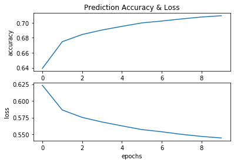

```python
#save the model and plot the loss
model.summary()
model.save('./chess_keras_model.h5')  # creates a HDF5 file with the model weights

plt.subplot(2,1,1)
plt.plot(history.history['acc'])
plt.title('Prediction Accuracy & Loss')
plt.ylabel('accuracy')

plt.subplot(2,1,2)
plt.plot(history.history['loss'])
plt.xlabel('epochs')
plt.ylabel('loss')
plt.show()
```

## 4. Validate the model

Validate it with the non-contaminated test set

We can also go thouth a random game and see the progression of the prediction through out the game.

```python
# model.load('keras/chess_model.h5')
_, test_accuracy = model.evaluate(test_x, test_y, batch_size=64)
print("test_accuracy: %f"%test_accuracy)
```

```
test_accuracy: 0.688356
```

```python
pgn = open('train.pgn')
```

```
Game result wht/blk:  1-0
```

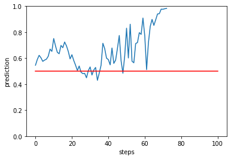

```python
game = chess.pgn.read_game(pgn)
result = game.headers['Result']
print("Game result wht/blk: ", result)

stat = []
board = game.board()
for move in game.mainline_moves():
    board.push(move)
    stat.append(model.predict(np.expand_dims(board2sample(board),axis=0)))

plt.plot(np.asarray(stat).flatten())
plt.plot([0, 100], [0.5, 0.5], 'r')
plt.ylim([0, 1])
plt.xlabel('steps')
plt.ylabel('prediction')
plt.show()
```